# Point patterns

WS 2016/2017

## Prerequisites

## setwd, library, data

```r
setwd("YOUR-PATH")
```

```r
raw_data <- read.table(file = "data/FS_UTM.csv",
                       header = TRUE,
                       sep = ";",
                       stringsAsFactors = FALSE,
                       quote = "")
```

## Create a spatial object

## Libraries and creation of sp object

Version 1

```r
library(sp)
library(rgdal)

sites <- SpatialPointsDataFrame(coords = cbind(raw_data$xUTM,raw_data$yUTM),
                                data = data.frame(raw_data[,2]),
                                proj4string = CRS("+init=epsg:32634")
                                )
class(sites)
```

```
## [1] "SpatialPointsDataFrame"
## attr(,"package")
## [1] "sp"
```

## Libraries and creation of sp object

Version 2

```r
sites <- raw_data
coordinates(sites) <- ~xUTM+yUTM
proj4string(sites) <- CRS("+init=epsg:32634")
```

## Plot it 2.0

Let's plot with `leaflet`. Since OpenStreetMap, google maps, etc. are global, we need a geographic coordinate system like WGS84

```r
is.projected(sites)
```

```
## [1] TRUE
```

```r
sites.wgs84 <- spTransform(sites, "+init=epsg:4326")
is.projected(sites.wgs84)
```

```
## [1] FALSE
```

What's this?!

## Plot it 2.0

```r
library(magrittr)
library(leaflet)

m1 <- leaflet() %>%
    addProviderTiles("Thunderforest.Landscape") %>%
        addMarkers(lng=sites.wgs84@coords[,1],
                   lat=sites.wgs84@coords[,2],
                   popup = sites.wgs84@data$Site.Name
                   )
m1
```

[interactive chart not shown]

## Export to Shapefile

```r
writeOGR(obj = sites,
         dsn = "./data",
         layer = "A_Sites",
         driver = "ESRI Shapefile",
         overwrite_layer = TRUE
         )
list.files("./data")
```

```
## [1] "A_Sites.dbf"    "A_Sites.prj"    "A_Sites.shp"    "A_Sites.shx"
## [5] "FS_UTM.csv"     "FS_UTM.xlsx"    "srtm_41_03.tif"
```

## Spatial Point Patterns

## Infos

*THE* references for this subject are: Baddeley et al. (2016), Baddeley (2008), Bivand et al. (2008), Diggle (2013)

And the best thing is: the authors are active developers of `R`. The package we will use in this topic very often is `spatstat`. A package so full of functions that the manual alone has over 1589 pages (as of 2016-02-03).

If you use the package in your research, do not forget to cite it (this holds true for every package used, including the base software `R` !):

```r
library(spatstat)
citation(package = "spatstat")
```

```
##
##
##   Adrian Baddeley, Ege Rubak, Rolf Turner (2015). Spatial Point
##   Patterns: Methodology and Applications with R. London: Chapman
##   and Hall/CRC Press, 2015. URL
##   http://www.crcpress.com/Spatial-Point-Patterns-Methodology-and-Applications-with-R/Baddeley-Rubak-Turner/9781482210200/
##
## If you use hybrid models, please also cite:
##
##   Adrian Baddeley, Rolf Turner, Jorge Mateu, Andrew Bevan (2013).
##   Hybrids of Gibbs Point Process Models and Their Implementation.
##   Journal of Statistical Software, 55(11), 1-43. URL
##   http://www.jstatsoft.org/v55/i11/.
##
## In survey articles, please cite the original paper on spatstat:
##
##   Adrian Baddeley, Rolf Turner (2005). spatstat: An R Package for
##   Analyzing Spatial Point Patterns. Journal of Statistical
##   Software 12(6), 1-42. URL http://www.jstatsoft.org/v12/i06/.
```

## Infos 2

Some resources for `spatstat` package:

- http://spatstat.github.io/
- https://cran.r-project.org/web/packages/spatstat/
- [manual](https://cran.r-project.org/web/packages/spatstat/spatstat.pdf)

[figure not shown]

## Create ppp object

```r
library(spatstat)
```

```r
sites.window <- owin(xrange = c(min(sites@coords[,1]),max(sites@coords[,1])),
                     yrange = c(min(sites@coords[,2]),max(sites@coords[,2]))
               )

sites.pp <- ppp(x = sites@coords[,1],
                y = sites@coords[,2],
                window = sites.window
                )
unitname(sites.pp) <- c("meter", "meters")
```

## inspect and plot

```r
str(sites.pp)
```

```
## List of 5
##  $ window    :List of 4
##   ..$ type  : chr "rectangle"
##   ..$ xrange: num [1:2] 443157 696380
##   ..$ yrange: num [1:2] 5012062 5145452
##   ..$ units :List of 3
##   .. ..$ singular  : chr "meter"
##   .. ..$ plural    : chr "meters"
##   .. ..$ multiplier: num 1
##   .. ..- attr(*, "class")= chr "units"
##   ..- attr(*, "class")= chr "owin"
##  $ n         : int 508
##  $ x         : num [1:508] 443157 459882 462115 466751 467930 ...
##  $ y         : num [1:508] 5105906 5095991 5088415 5089685 5109462 ...
##  $ markformat: chr "none"
##  - attr(*, "class")= chr "ppp"
```

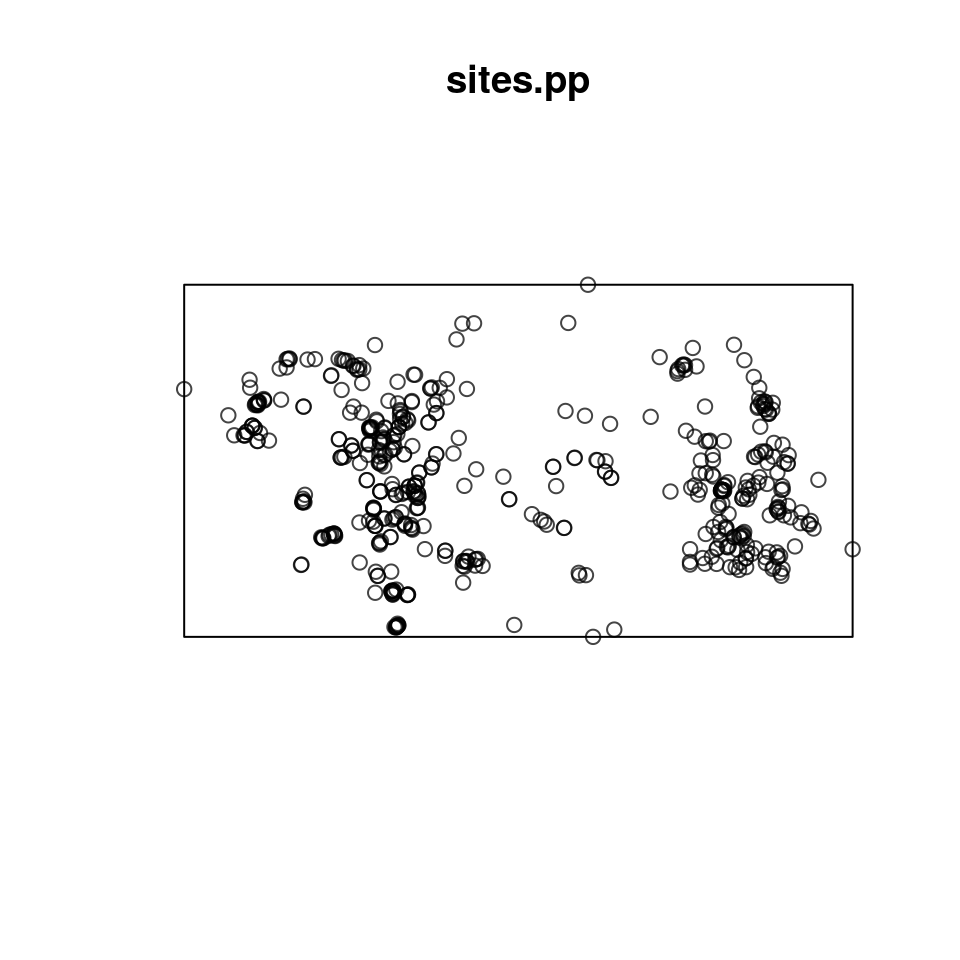

```r
plot(sites.pp)
```

## Measures of Central tendency

Mean center (`mc`) and standard distance (`stdist`)

```r
mc <- cbind(sum(sites@coords[,1])/length(sites@coords[,1]),
            sum(sites@coords[,2])/length(sites@coords[,2])
            )

stdist <- sqrt(sum((sites@coords[,1]-mean(sites@coords[,1]))^2 +
                   (sites@coords[,2]-mean(sites@coords[,2]))^2) /
               length(sites@coords[,1])
               )
```

## Measures of Central tendency

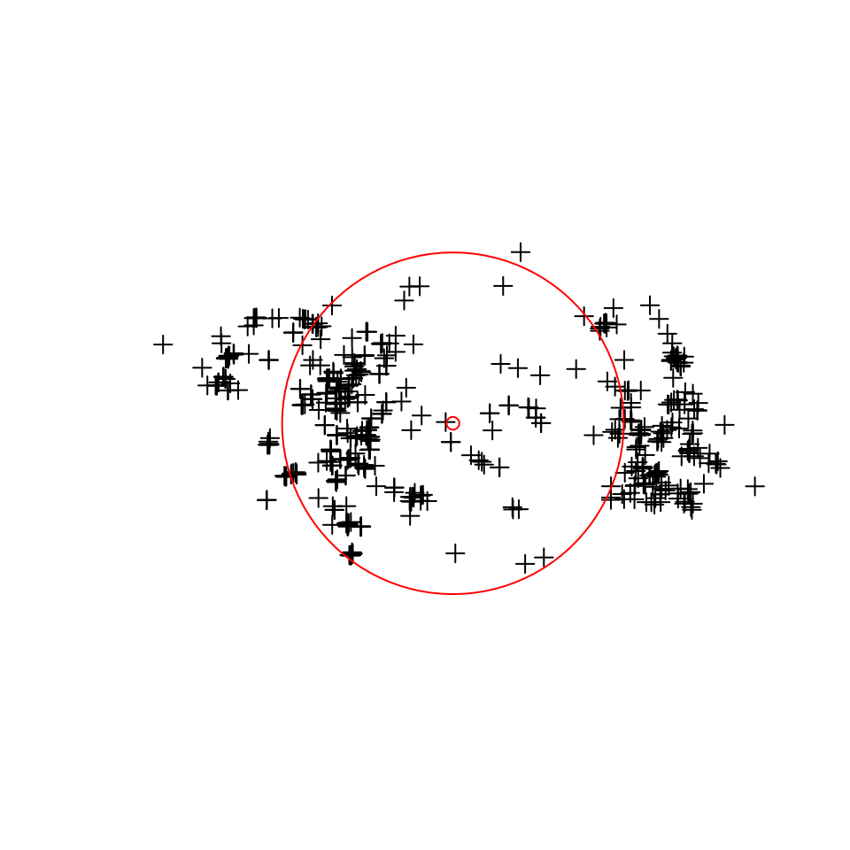

```r
plot(sites)

points(mc, col ="red")

library(plotrix)
draw.circle(x = mc[1],
            y = mc[2],
            radius = stdist,
            border = "red"
            )
```

## First-order effects

## Global intensity

Global intensity = Number of points per area

```r
## A = a * b
area.sqm <- diff(sites.pp$window$xrange) * diff(sites.pp$window$yrange)
area.sqkm <- area.sqm*10^-6
# area <- area/1000000
area.sqkm
```

```
## [1] 33777.36
```

```r
## calculate intensity
intensity <- sites.pp$n/area.sqkm
intensity
```

```
## [1] 0.01503966
```

## Local intensity

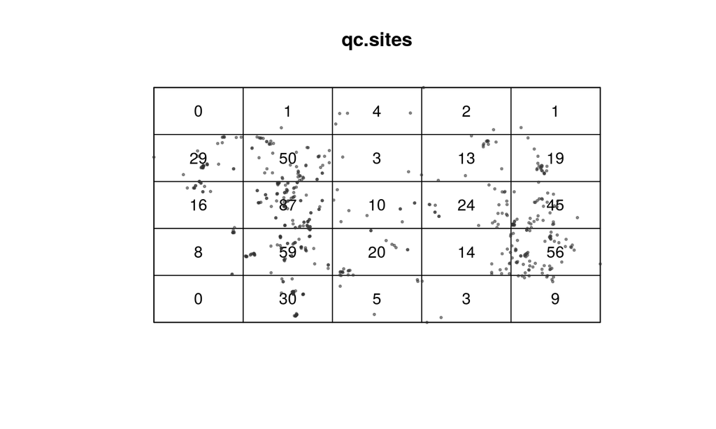

```r
qc.sites <- quadratcount(X = sites.pp)

plot(qc.sites)
points(sites.pp, pch = 20, cex = .5, col = rgb(.2,.2,.2,.5))
```

## Local intensity

The question is: do the quadratcounts indicate CSR? To check we use a \(\chi^2\) test approach

(relation between observed (i.e. empirical) and expected (i.e. theoretical, here CSR) amounts of points in quadrants)

```r
qt.sites <- quadrat.test(X = sites.pp)
qt.sites
```

```
##
##  Chi-squared test of CSR using quadrat counts
##  Pearson X2 statistic
##
## data:  sites.pp
## X2 = 610.11, df = 24, p-value < 2.2e-16
## alternative hypothesis: two.sided
##
## Quadrats: 5 by 5 grid of tiles
```

## Local intensity

observed (lop left) | expected (top right) | Pearson residual (bottom)

+/- 2 = unusual; > +/- 2 = gross departure from fitted model

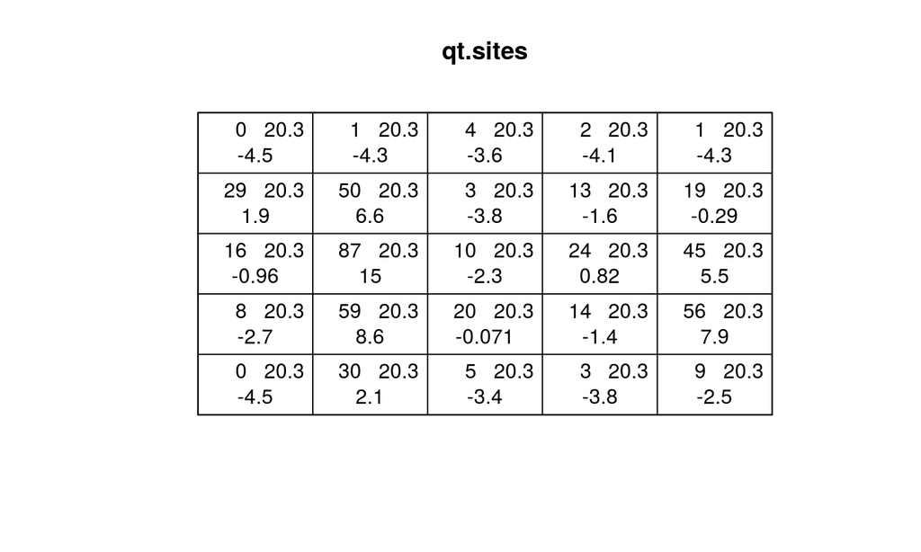

```r
plot(qt.sites)
```

## Density calculation - 1st approach

**Amount of events within pixel**…in imprecise language: a histogram in space. This is a step by step example but the code is rather inefficient.

Step 1 - data preparation

```r
cs <- 10000    # cellsize
# enlarge the study area by ONE pixel (in E-W and N-S direction)
xmin <- sites.pp$window$xrange[1] - cs/2
xmax <- sites.pp$window$xrange[2] + cs/2
ymin <- sites.pp$window$yrange[1] - cs/2
ymax <- sites.pp$window$yrange[2] + cs/2
## calculate the number of rows/columns
## (add 1 just because a pixel might get "lost" through the rounding operation)
rows  <- round((ymax-ymin)/cs, 0) + 1
columns <- round((xmax-xmin)/cs, 0) + 1

z <- cbind(1:(columns*rows)) # create a vector with all grid cells
df <- data.frame(z) # create a data.frame of it
```

## Density calculation - 1st approach

Step 2 - create grid topology

```r
# create a topological description of a grid
gt <- GridTopology(cellcentre.offset = c(sites.pp$window$xrange[1] - cs/2,
                                         sites.pp$window$yrange[1] - cs/2),
                   cellsize = c(cs,cs),
                   cells.dim = c(columns,rows))
gt
```

```
##                       X1      X2
## cellcentre.offset 438157 5007062
## cellsize           10000   10000
## cells.dim             27      15
```

## Density calculation - 1st approach

Step 3 - create grid

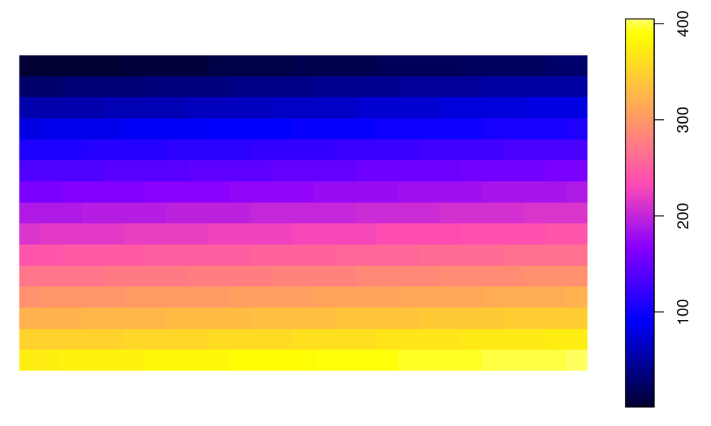

```r
sgdf <- SpatialGridDataFrame(grid = gt,
                             data = df,
                             proj4string = CRS("+init=epsg:32634")
                             )
plot(sgdf)
```

## Density calculation - 1st approach

Step 4 - calculate density

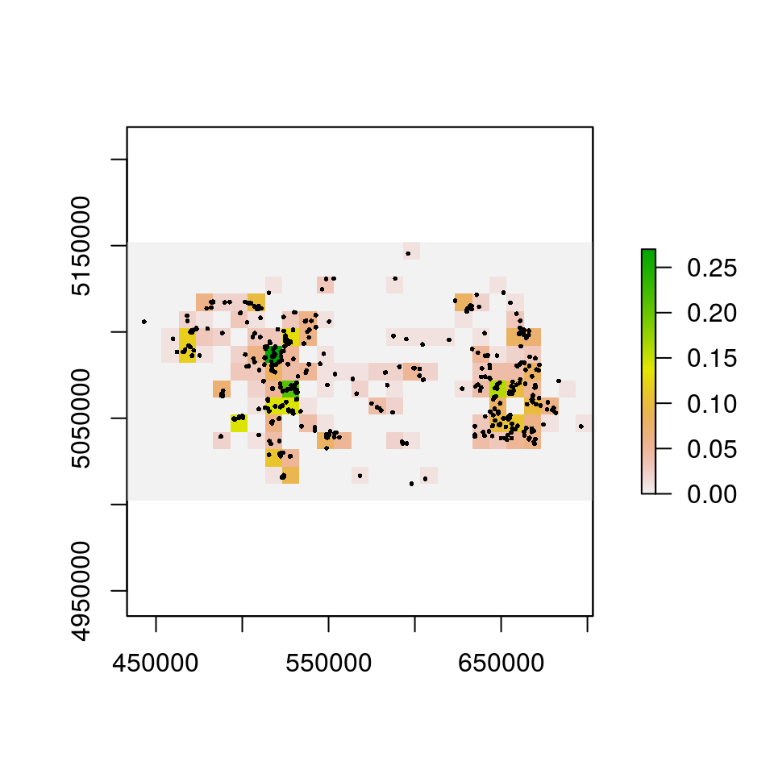

```r
for (i in seq(along=coordinates(gt)[,1])){
    ## because the coordinate is defined for the
    ## center of the cell, the half cellsize
    ## is substracted
    x <- coordinates(gt)[i,1] - cs/2
    y <- coordinates(gt)[i,2] - cs/2

    ## which events lie within the x/y direction?
    xi <- which(sites.pp$x > x &
                sites.pp$x < x + cs)
    yi <- which(sites.pp$y > y &
                sites.pp$y < y + cs)

    ## how many objects in x and y direction intersect?
    pz <- length(intersect(xi,yi))

    ## divide the number of points by the area
    sgdf@data$z[i]<- pz / (cs/1000)^2
}

plot(raster::raster(sgdf))
points(sites.pp$x, sites.pp$y, pch=16, cex=0.4)
```

## Density calculation - 2nd approach

**Kernel density estimation**; again here performed step by step and rather inefficiently/partially incorrect coded. Use it to understand the concept.

- for all cells
- get cell center
  - for all points
  - calculate distance to cell center; Euclidean distance -> \(\sqrt{(x_i-x)^2+(y_i-y)^2}\)
  - weight the distance according to kernel function
- write value in pixel

## Density calculation - 2nd approach

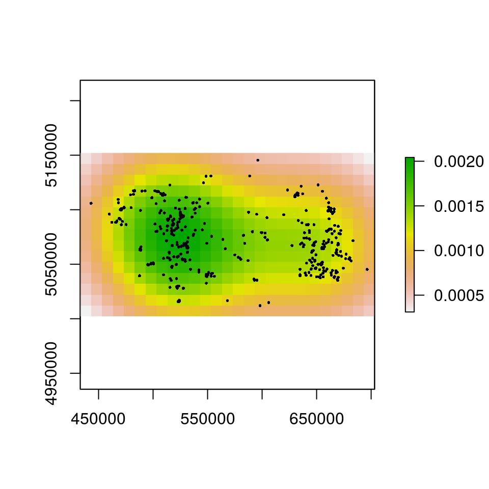

```r
sgdf_kde <- sgdf
## kernel bandwidth
sd <- 50000

for (i in seq(along=coordinates(gt)[,1])){
    x <- coordinates(gt)[i,1]
    y <- coordinates(gt)[i,2]
    g2 <- 0
    for (j in seq(along=sites.pp$x)){
        distance <- sqrt((sites.pp$x[j] - x)^2 +
                         (sites.pp$y[j] - y)^2
                         )
        g1 <- dnorm(distance, mean=0, sd=sd)
        g2 <- g2 + g1
    }
    sgdf_kde@data$z[i]<- g2
}

library(raster)
plot(raster(sgdf_kde))
points(sites.pp$x, sites.pp$y, pch=16, cex=0.4)
```

## Density calculation - 3rd approach

**Kernel density estimation** using the built in function of `spatstat`. Since the package is great, it is perfectly coded and fast.

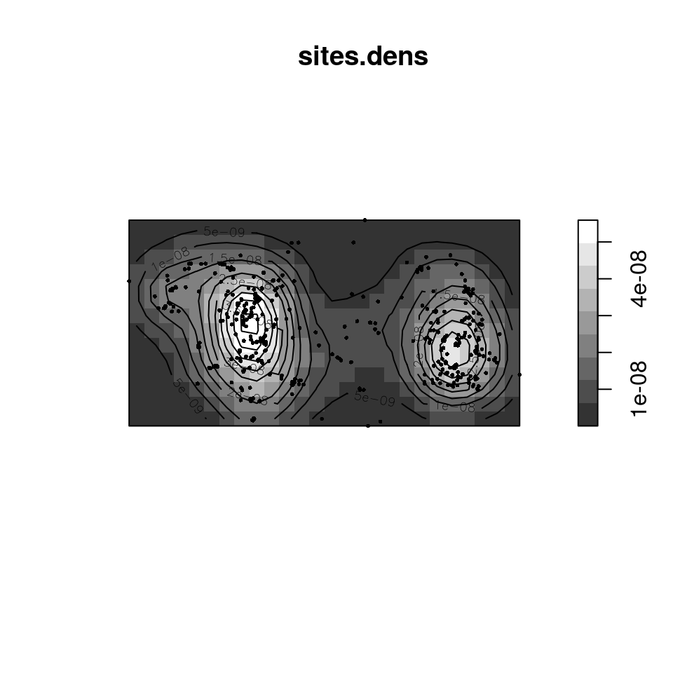

```r
cs <- 10000
sd <- 50000

sites.dens <- density(x = sites.pp,
                      bw = sd,
                      eps=cs,
                      edge=FALSE,
                      at="pixels"
                      )

plot(sites.dens, col = grey(seq(0.2,1,.1)))
contour(sites.dens, add=T)
points(sites.pp$x, sites.pp$y, pch=16, cex=0.4)
```

## Density calculation - 3rd approach

Use another measure for `sd` - in this case three times the mean nearest neighbor distance.

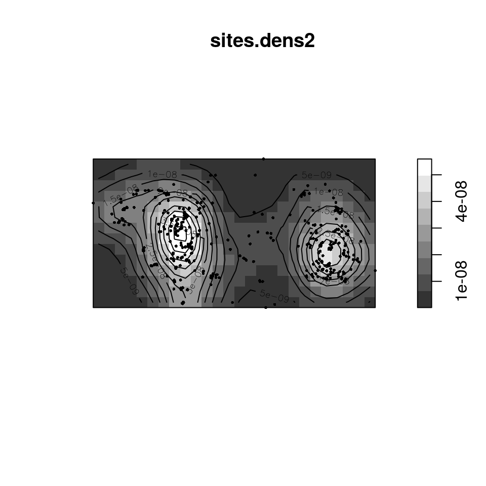

```r
sdev <- 3*mean(nndist(sites.pp))

sites.dens2 <- density(x = sites.pp,
                       bw = sdev,
                       eps=cs,
                       edge=TRUE,
                       at="pixels"
                       )

plot(sites.dens2, col = grey(seq(0.2,1,.1)))
contour(sites.dens2, add=T)
points(sites.pp$x, sites.pp$y, pch=16, cex=0.4)
```

## Second-order effects

## Nearest-neighbor distance

```r
sites.nn <- nndist(X = sites.pp)

str(sites.nn)
```

```
##  num [1:508] 19443 7899 3519 132 3026 ...
```

```r
mean(sites.nn)
```

```
## [1] 1623.151
```

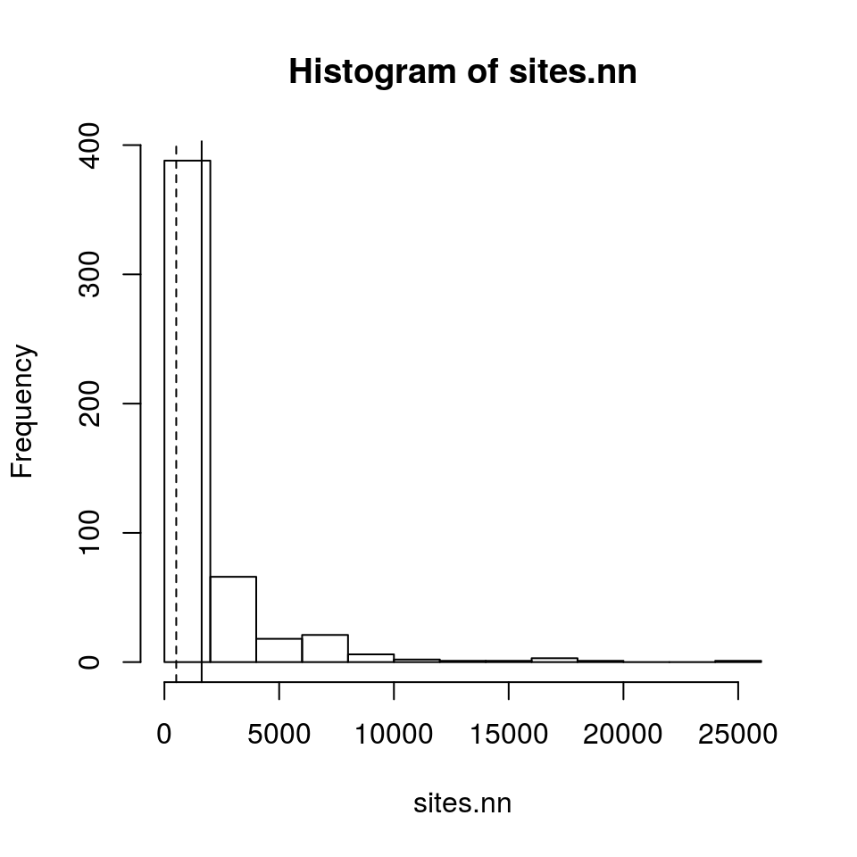

```r
hist(sites.nn)
abline(v=mean(sites.nn))
abline(v=median(sites.nn), lty=2)
```

## Nearest neighbor Distance – Clark and Evans’ R

\(R = \bar{d_{min}} / \frac{1}{2\sqrt{\lambda}}\)

"An \(R\) value of less than 1 indicates of a tendency toward clustering, since it shows that observed nearest neighbor distances are shorter than expected. An R value of more than 1 indicatives of a tendency toward evenly spaced events" (O'Sullivan & Unwin 2010, 144)

```r
nnE <- 1/(2*sqrt((sites.pp$n/area.sqm)))
nnE
```

```
## [1] 4077.097
```

```r
R.sites <- mean(sites.nn)/nnE
R.sites
```

```
## [1] 0.3981143
```

## G function

First approach based on theoretical assumptions, i.e. CSR

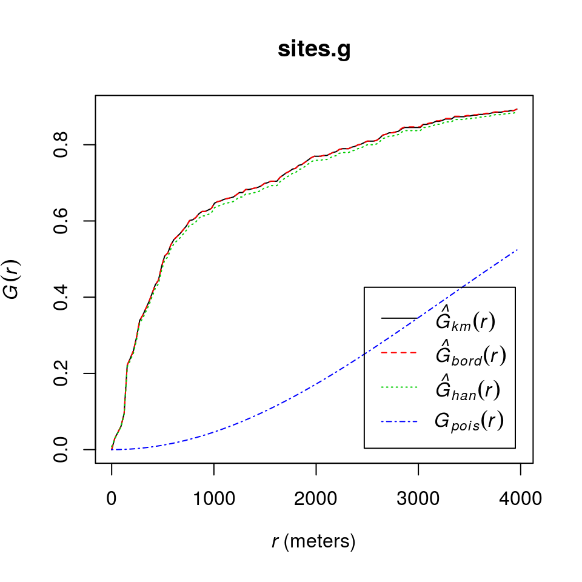

```r
sites.g <- Gest(sites.pp)
plot(sites.g)
```

## G function

Second approach based on simulations of a theortical process, i.e. CSR

```r
sites.g.env <- envelope(sites.pp,
                        fun = Gest,
                        nsim = 10)
```

```
## Generating 10 simulations of CSR  ...
## 1, 2, 3, 4, 5, 6, 7, 8, 9,  10.
##
## Done.
```

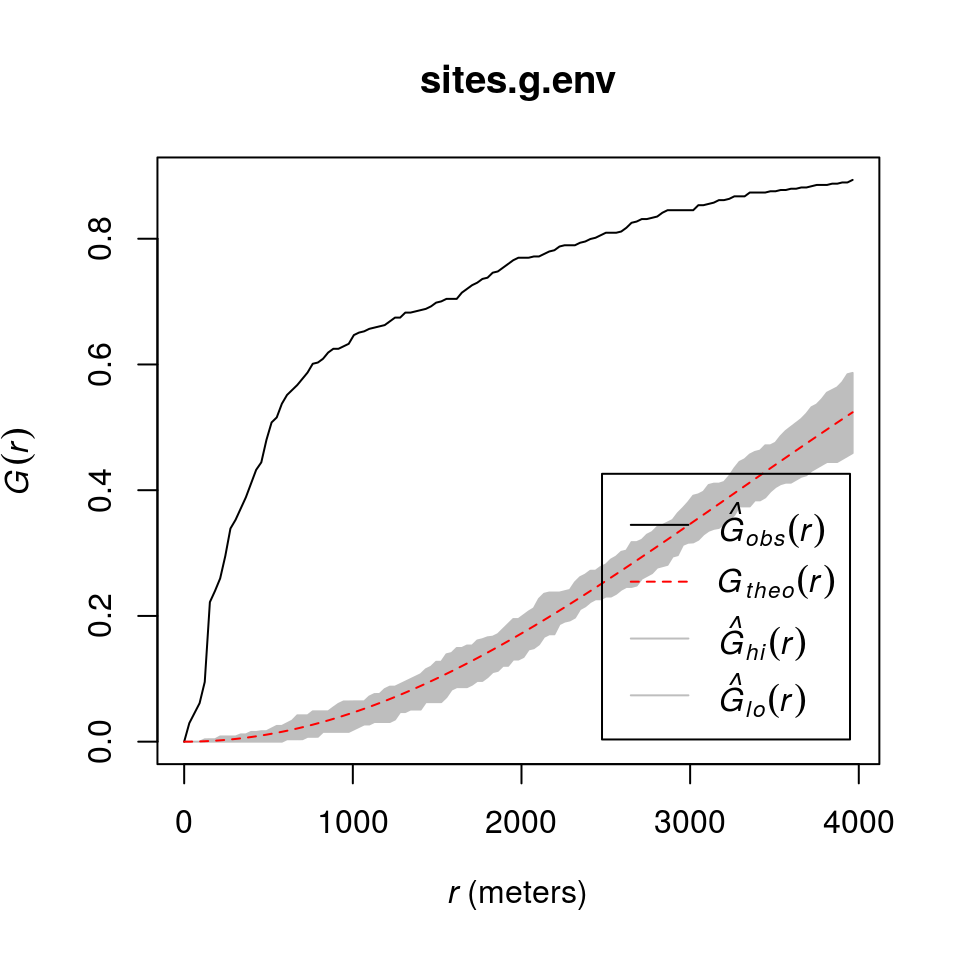

```r
plot(sites.g.env)
```

## F function

First approach based on theoretical assumptions, i.e. CSR

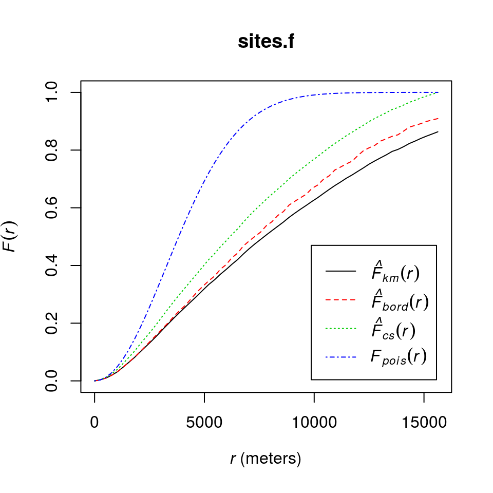

```r
sites.f <- Fest(sites.pp)
plot(sites.f)
```

## F function

Second approach based on simulations of a theortical process, i.e. CSR

```r
sites.f.env <- envelope(sites.pp,
                        fun = Fest,
                        nsim = 10)
```

```
## Generating 10 simulations of CSR  ...
## 1, 2, 3, 4, 5, 6, 7, 8, 9,  10.
##
## Done.
```

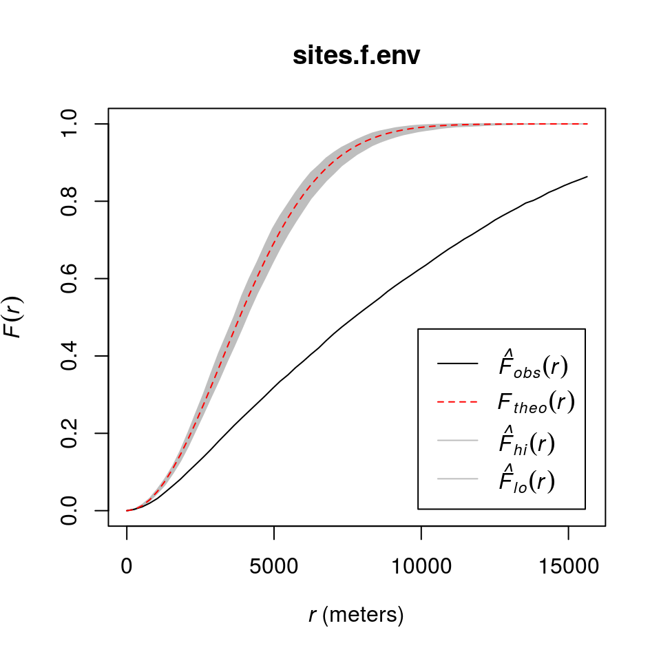

```r
plot(sites.f.env)
```

## K function

First approach based on theoretical assumptions, i.e. CSR

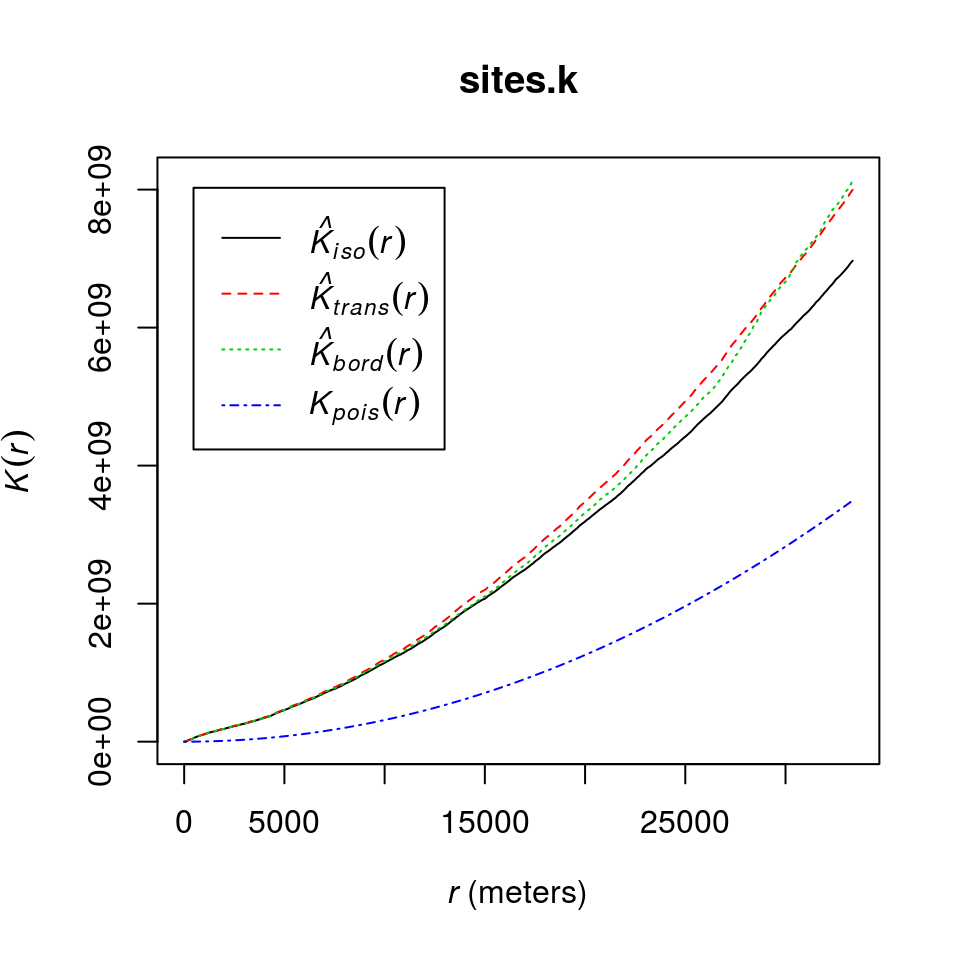

```r
sites.k <- Kest(sites.pp)
plot(sites.k)
```

## K function

Second approach based on simulations of a theortical process, i.e. CSR

```r
sites.k.env <- envelope(sites.pp,
                        fun = Kest,
                        nsim = 10)
```

```
## Generating 10 simulations of CSR  ...
## 1, 2, 3, 4, 5, 6, 7, 8, 9,  10.
##
## Done.
```

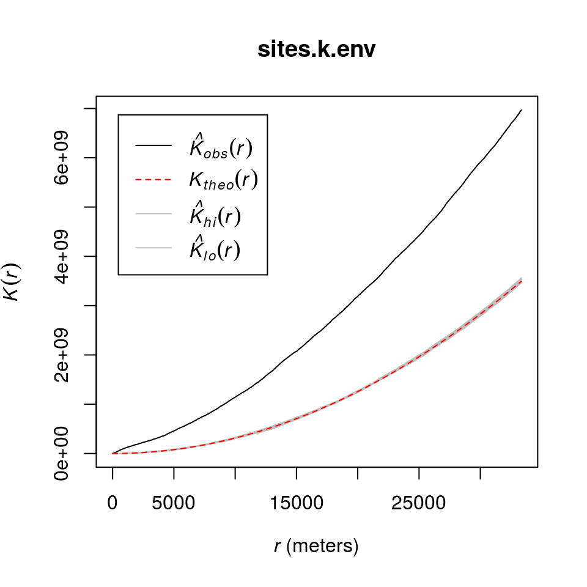

```r
plot(sites.k.env)
```

## L function

First approach based on theoretical assumptions, i.e. CSR

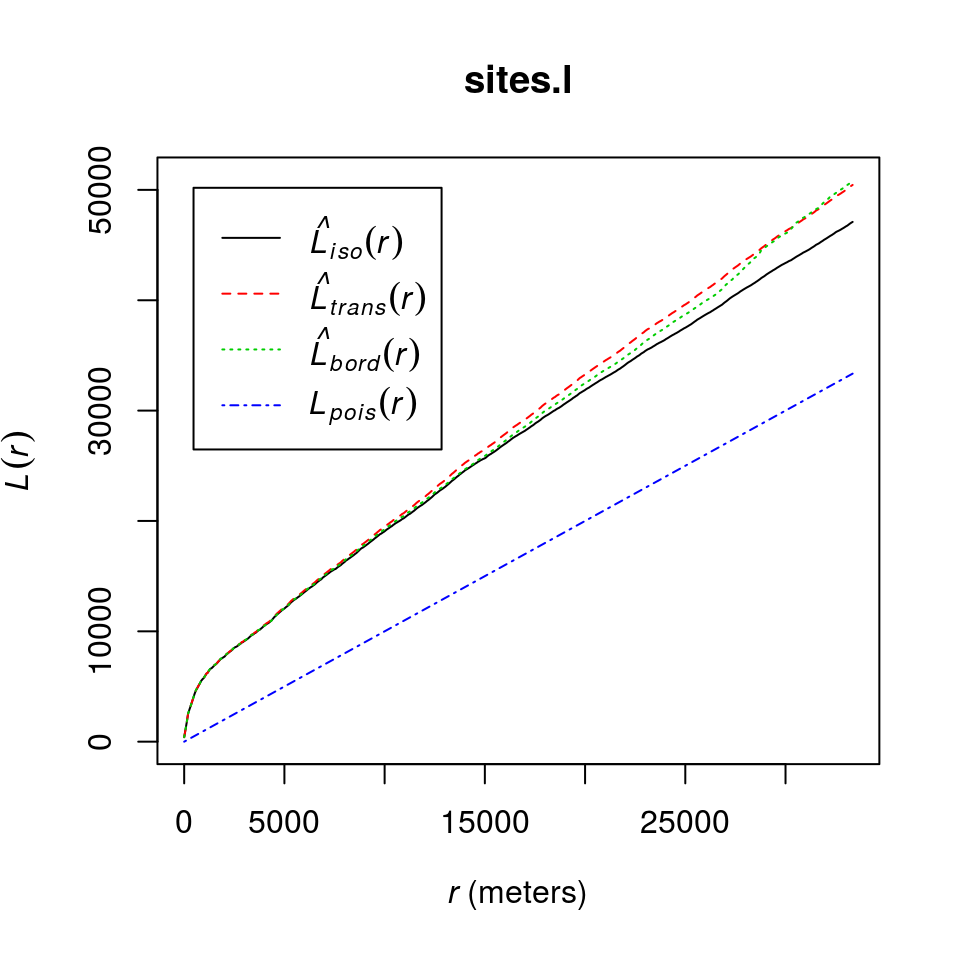

```r
sites.l <- Lest(sites.pp)
plot(sites.l)
```

## L function

Second approach based on simulations of a theortical process, i.e. CSR

```r
sites.l.env <- envelope(sites.pp,
                        fun = Lest,
                        nsim = 10)
```

```
## Generating 10 simulations of CSR  ...
## 1, 2, 3, 4, 5, 6, 7, 8, 9,  10.
##
## Done.
```

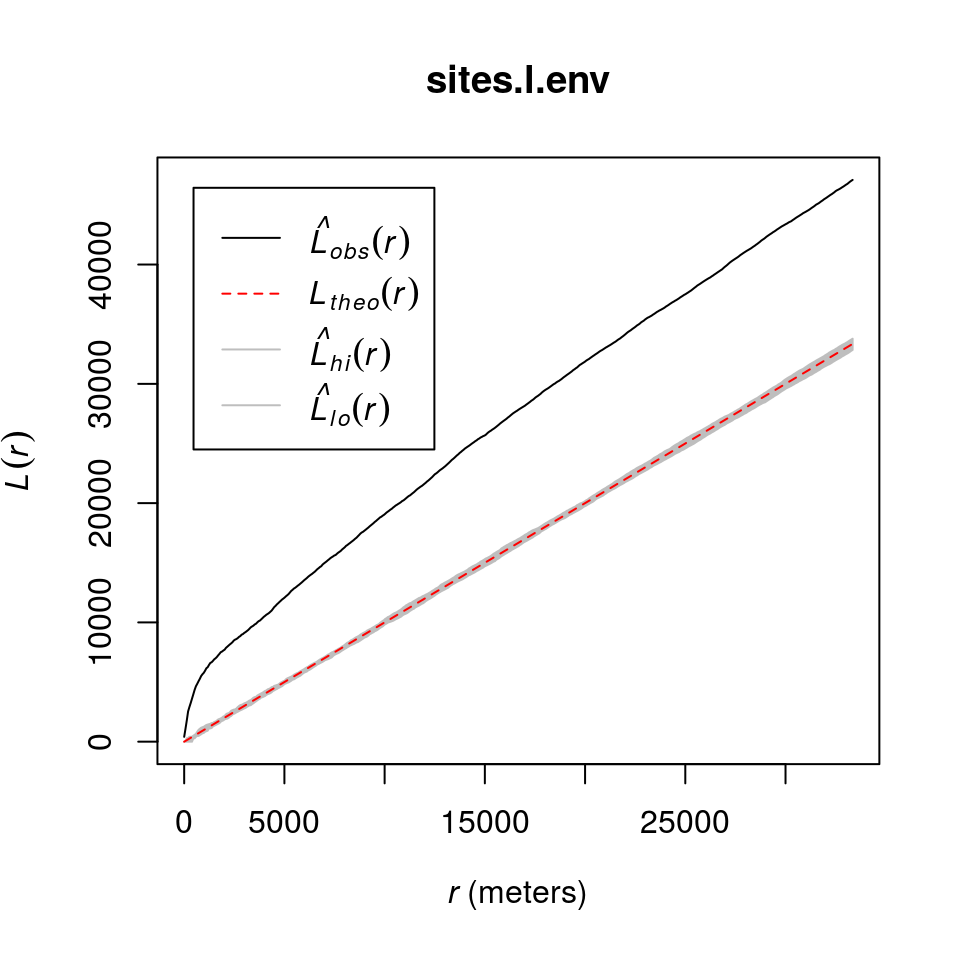

```r
plot(sites.l.env)
```

## From global to local measure

## G and moving window

**Where** are the points clustered/ordered/…

Procedure

- take a raster
- choose a moving window
- define sample radius for G-function
- check [cell by cell] characteristics of G

Preparation

```r
sgdf.g <- sgdf # grid
#sites.nn # nearest neighbors
#sites.window # window
radius <- 25000   # Radius of moving window
r <- seq(0, radius, 50) # Disctance vector for G; it is not advised to use it!
```

## G and moving window

```r
for (i in seq(along=sgdf.g@data$z))  {
    xr <- coordinates(sgdf.g)[i,1]
    yr <- coordinates(sgdf.g)[i,2]
    distances <- sqrt((sites.pp$x -xr)^2 + (sites.pp$y -yr)^2)
    ## Which points are within the moving window?
    index <- which(distances<radius)

    ## at least three points need to be in the moving window
    if (length(index) > 2 ) {
        x <- sites.pp$x[index]
        y <- sites.pp$y[index]
        name <- sites$Site.Name[index]
        sites2 <- SpatialPointsDataFrame(cbind(x, y),
                                         as.data.frame(name),
                                         proj4string= CRS("+init=epsg:32634")
                                         )
        ## Point pattern from points in moving window
        sites.ppt <- ppp(sites2@coords[,1],sites2@coords[,2],window=sites.window)
        g <- Gest(sites.ppt, r=r)
        ## mean differnce "theoretical - empirical"; positiv = orered
        meandiff <-  mean(g$theo-g$km)
        sgdf.g@data$z[i] <- meandiff
    }
    else {sgdf.g@data$z[i] <-NA}
}
```

[output not shown]

[output cut: 43 more lines]

[output not shown]

## G and moving window

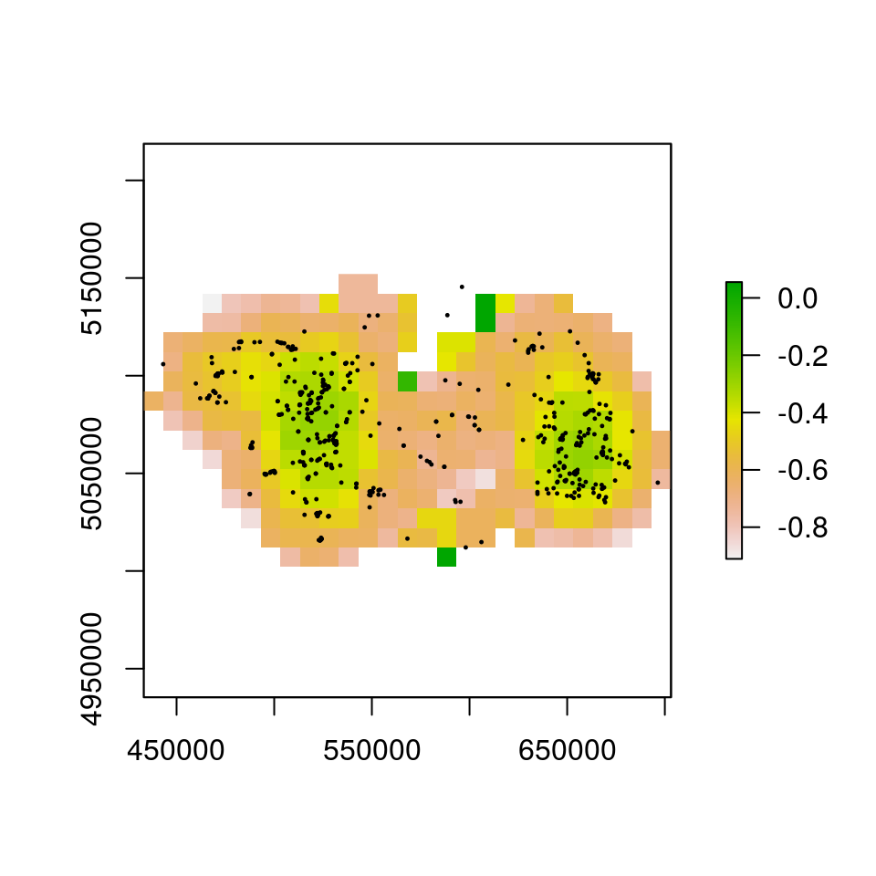

```r
library(raster)
plot(raster(sgdf.g))
points(sites, cex = .2, pch = 19)
```

## F and moving window

**Where** are the points clustered/ordered/…

Procedure

- take a raster
- choose a moving window
- define sample radius for G-function
- check [cell by cell] characteristics of F

Preparation

```r
sgdf.f <- sgdf # grid
#sites.nn # nearest neighbors
#sites.window # window
radius <- 25000   # Radius of moving window
r <- seq(0, radius, 50) # Disctance vector for G; it is not advised to use it!
```

## F and moving window

```r
for (i in seq(along=sgdf.f@data$z))  {
    xr <- coordinates(sgdf.f)[i,1]
    yr <- coordinates(sgdf.f)[i,2]
    distances <- sqrt((sites.pp$x -xr)^2 + (sites.pp$y -yr)^2)
    ## Which points are within the moving window?
    index <- which(distances<radius)

    ## at least three points need to be in the moving window
    if (length(index) > 2 ) {
        x <- sites.pp$x[index]
        y <- sites.pp$y[index]
        name <- sites$Site.Name[index]
        sites2 <- SpatialPointsDataFrame(cbind(x, y),
                                         as.data.frame(name),
                                         proj4string= CRS("+init=epsg:32634")
                                         )
        ## Point pattern from points in moving window
        sites.ppt <- ppp(sites2@coords[,1],sites2@coords[,2],window=sites.window)
        f <- Fest(sites.ppt, r=r)
        ## mean differnce "theoretical - empirical"; positiv = orered
        meandiff <-  mean(f$theo-f$km)
        sgdf.f@data$z[i] <- meandiff
    }
    else {sgdf.f@data$z[i] <-NA}
}
```

[output not shown]

[output cut: 43 more lines]

[output not shown]

## F and moving window

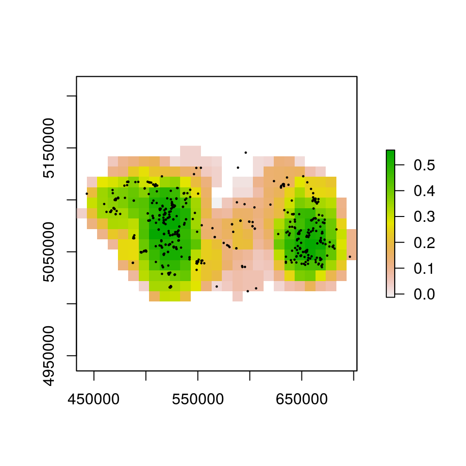

```r
library(raster)
plot(raster(sgdf.f))
points(sites, cex = .2, pch = 19)
```

## G and F moving window

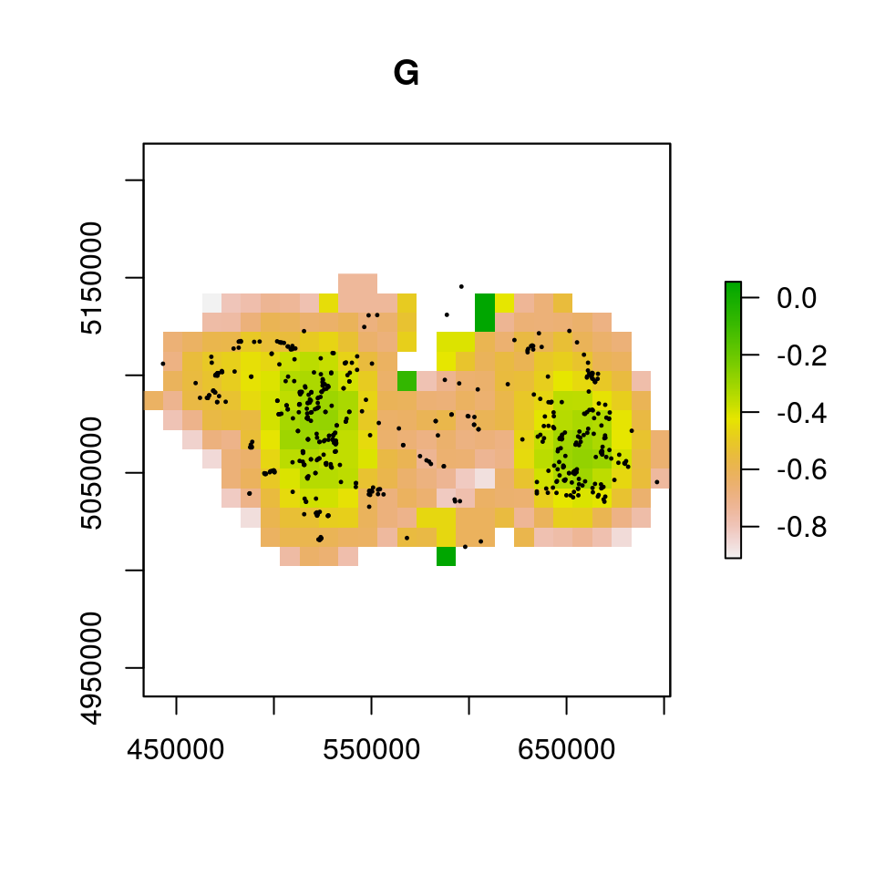

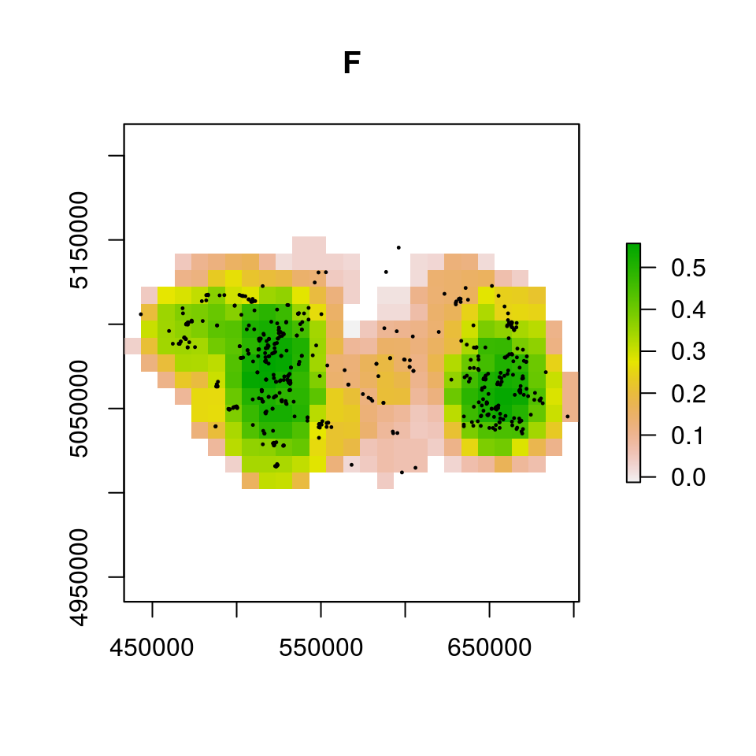

## References

Baddeley, A., 2008. *Analysing spatial point patterns in R*, CSIRO; University of Western Australia. Available at: http://www.csiro.au/files/files/pn0y.pdf.

Baddeley, A., Rubak, E. & Turner, R., 2016. *Spatial point patterns: Methodology and applications with r*, CRC Press, Taylor & Francis Group.

Bivand, R.S., Pebesma, E.J. & Gómez-Rubio, V., 2008. *Applied Spatial Data Analysis with R*, New York: Springer.

Diggle, P.J., 2013. *Statistical Analysis of Spatial and Spatio-Temporal Point Patterns, Third Edition* 3rd ed., Boca Raton: Chapman; Hall/CRC.